# Task 1 - Palmetto binary logistic regression

Jaxon Stuhr

1/28/2022

## Overview

This document examines Florida palmetto data from the Archbold Biological Station in south-central Florida. Observations occured between 1981 and 2017. Below, releveant data is visualized and two binary logistic regression models are developed to predict the species of an observed plant based on characteristics found in the data. The model performance is compared, a superioir model is selected, and the results and predictive capacity of this model are displayed.

## Data Visualization

```r
# read in data
palmetto_raw = read_csv(here("data", "palmetto.csv"))
# species: 1 = Serenoa repens, 2 = Sabal etonia to start
palmetto = palmetto_raw %>%
  # select applicable variables
  select(species, height:green_lvs) %>%
  # relabel species
  mutate(species = case_when(
    species == 1 ~ "Serenoa repens",
    species == 2 ~ "Sabal etonia"
  )) %>%
  # make species a factor
  mutate(species = factor(species)) %>%
  na.omit()
# Sabal etonia = 0, serenoa repens = 1
# class(palmetto$species)
# levels(palmetto$species)
# Sabal and serenoa subsets
sabal = palmetto %>%
  filter(species == "Sabal etonia")
serenoa = palmetto %>%
  filter(species == "Serenoa repens")
```

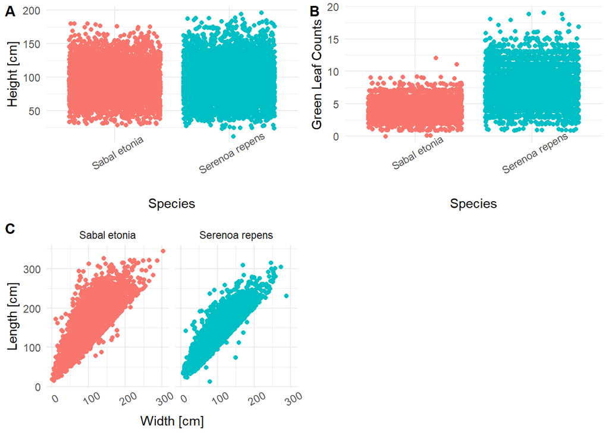

```r
# Data Viz
plot1 = ggplot(palmetto, aes(x = species, y = height, color = species)) +
  geom_jitter() +
  theme_minimal() +
  labs(x = "Species", y = "Height [cm]") +
  theme(axis.text.x = element_text(angle = 30)) +
  theme(legend.position="none")

plot2 = ggplot(palmetto, aes(x = species, y = green_lvs, color = species)) +
  geom_jitter() +
  theme_minimal() +
  labs(x = "Species", y = "Green Leaf Counts") +
  theme(axis.text.x = element_text(angle = 30)) +
  theme(legend.position="none")

plot3 = ggplot(palmetto, aes(x = width, y = length, color = species)) +
  geom_point() +
  facet_wrap(~species) +
  theme_minimal() +
  labs(x = "Width [cm]", y = "Length [cm]") +
  theme(axis.text.x = element_text(angle = 30)) +
  theme(legend.position="none")

# Combine plots in figure
plot_grid(plot1, plot2, plot3, labels = c('A', 'B', 'C'), label_size = 12)
```

Figure 1: Exploring the predictive capacity of canopy height (A), width (C), length(C), and number of green leaves (B), on plant species (*Sabal etonia* or *Serenoa repens*) for south-central Florida palmetto data collected between 1981 and 2017

Based on the exploratory plots above, I expect green leaf counts and measured length to have significant predictive capacity, based on the increased leaf counts for *Serenoa repens* (mean count = 7.5 vs 4.02) and greater lengths for *Sabal etonia* (mean length = 143.35 [cm] vs 120.07 [cm]). Width and height will likely have less predictive capacity.

## Binary Logistic Regression: Model Comparison and Training

```r
# build functions and models
f1 <- species ~ height + length + width + green_lvs

regression1 <- glm(formula = f1,
                    data = palmetto,
                    family = "binomial")

f2 <- species ~ height + width + green_lvs

regression2 <- glm(formula = f2,
                    data = palmetto,
                    family = "binomial")
```

```r
# AICc comparison of models
# AICcmodavg::aictab(list(regression1, regression2))
```

```r
# 10-fold cross validation of models
set.seed(57)
# tr_ctrl <- trainControl(method = "cv", number = 10)
tr_ctrl <- trainControl(method = "repeatedcv", number = 10, repeats = 10)

# Train the model
model1 <- train(f1, data = palmetto,
               method = "glm", family = 'binomial',
               trControl = tr_ctrl)
# model1

model2 <- train(f2, data = palmetto,
               method = "glm", family = 'binomial',
               trControl = tr_ctrl)
# model2
```

Based on both AIC scores and 10-fold cross validation, Model 1 which predicts species as a function of canopy length, height, weight, and leaf counts, outperformed Model 2, which excluded canopy length. This is not surprising as canopy length was expected to have significant predictive capacity. The final model is expressed below:

$$\begin{aligned}
\log\left[ \frac { \widehat{P( \operatorname{species} = \operatorname{Serenoa\ repens} )} }{ 1 - \widehat{P( \operatorname{species} = \operatorname{Serenoa\ repens} )} } \right] &= -3.23 + 0.03(\operatorname{height}) - 0.05(\operatorname{length}) - 0.04(\operatorname{width})\ + \\
&\quad 1.91(\operatorname{green\_lvs})
\end{aligned}$$

The coefficients in this model align with our predictions, showing a strong relationship between leaf count and probability of a *Serenoa repens*, a weaker relationship between canopy length and *Sabal etonia*, and even weaker relationships associated with canopy width and height. A model summary table is displayed below.

```r
model_tidy = broom::tidy(regression1)

kbl(model_tidy, caption = "Table 1: Model Results Summary") %>%
  kable_classic(full_width = F, html_font = "Cambria")
```

Table 1: Model Results Summary

| term | estimate | std.error | statistic | p.value |
| --- | --- | --- | --- | --- |
| (Intercept) | -3.2266851 | 0.1420708 | -22.71180 | 0 |
| height | 0.0292173 | 0.0023061 | 12.66984 | 0 |
| length | -0.0458233 | 0.0018661 | -24.55600 | 0 |
| width | -0.0394434 | 0.0021000 | -18.78227 | 0 |
| green_lvs | 1.9084747 | 0.0388634 | 49.10728 | 0 |

## Binary Logistic Regression: Model Performance

```r
# use broom::augment to add predicted species to table
model_fitted = regression1 %>%
  broom::augment(type.predict = "response") %>%
  # add predicted species column
  mutate("classification" = case_when(
    .fitted < .5 ~ "Sabal etonia",
    .fitted > .5 ~ "Serenoa repens"
  )) %>%
  # add correctly classified column
  mutate("correct_classification" = case_when(
    species == classification ~ "Yes",
    species != classification ~ "No"
  ))
```

```r
# build prediction table with counts and percents
prediction_table = model_fitted %>%
  tabyl(species, correct_classification) %>%
  adorn_percentages() %>%
  adorn_pct_formatting(digits = 2) %>%
  adorn_ns()

# display prediction table
kable(prediction_table,
      col.names = c("Species", "Incorrectly Classified (%, Count)", "Correctly Classified (%, Count)"),
      caption = "Table 2: Predictive Performance of Binomial Regression Model, Classification Accurace by Species") %>%
  kable_classic(full_width = F, html_font = "Cambria")
```

Table 2: Predictive Performance of Binomial Regression Model, Classification Accurace by Species

| Species | Incorrectly Classified (%, Count) | Correctly Classified (%, Count) |
| --- | --- | --- |
| Sabal etonia | 7.38% (454) | 92.62% (5701) |
| Serenoa repens | 9.23% (564) | 90.77% (5548) |

The model performed well, classifying both species correctly with over 90% accuracy. The model predicted the species of 12,267 observed plants, and accurately classified 11,249 based on canopy height, width, length, and leaf counts.

## Data Citation

Abrahamson, W.G. 2019. Survival, growth and biomass estimates of two dominant palmetto species of south-central Florida from 1981 - 2017, ongoing at 5-year intervals ver 1. Environmental Data Initiative. https://doi.org/10.6073/pasta/f2f96ec76fbbd4b9db431c79a770c4d5